# Homework 8

Bingying Liu

April 15, 2020

### Question 1: Biased coin problem:

Suppose we have univariate data $y_1,…,y_n|\theta \sim Bernoulli(\theta)$ and wish to test: $H_0:\theta=0.5$ vs. $H_1:\theta \neq 0.5$.

#### Part (a): Formulate this hypothesis testing problem in a Bayesian way. Specify all the necessary steps and come up with your own priors where necessary.

**Steps:**  
1. Put a prior on actual hypotheses, that is on $\pi(H_0) = Pr(H_0)$ and $\pi(H_1) = Pr(H_1)$. In this case, since we have no prior information, we set $Pr(H_0) = Pr(H_1) = 0.5$.  
2. Put a prior on the parameter in each model. In this case, we set an uninformative prior $\pi(\theta) = Beta(1,1) = 1$.  
3. Compute marginal posterior probabilities for each hypothesis: $Pr(H_0|Y)$ and $Pr(H_1|Y)$.  
4. Conclude based on the magnitude of $Pr(H_1|Y) relative to $Pr(H_0|Y)$.

#### Part (b): Derive and simplify the marginal likelihoods $L[Y|H_0]$ and $L[Y|H_1]$.

$\begin{align*} L[Y|H_0] &= \int_{\theta=0.5} p(Y, \theta|H_0) d\theta \\ &= \int_{\theta=0.5} L(Y|H_0, \theta) \pi(\theta|H_0) d\theta\\ &= 0.5^{\sum y_i} 0.5^{n-\sum y_i} \\ &= 0.5^{n} \end{align*}$

$\begin{align*} L[Y|H_1] &= \int_{\theta=0}^1 p(Y, \theta|H_1) d\theta \\ &= \int_{\theta=0}^1 L(Y|H_1, \theta) \pi(\theta|H_1) d\theta\\ &= \int_{\theta=0}^1 \theta^{\sum y_i} (1-\theta)^{n- \sum y_i} Beta(1,1) d\theta\\ &= B(\sum y_i + 1, n - \sum y_i + 1) \end{align*}$

#### Part (c): Derive the Bayes factor in favor of $H_1$. Also, derive the posterior probability of $H_1$ being true. Simplify both as much as possible.

$\begin{align*} BF_{10} = \frac{L[Y|H_1]}{L[Y|H_0]} = \frac{B(\sum y_i + 1, n - \sum y_i + 1)}{0.5^n} \end{align*}$

$\begin{align*} Pr[H_1 | Y] = \frac{1}{BF_{01} + 1} = \frac{1}{\frac{1}{BF_{10}} + 1} = \frac{1}{\frac{0.5^n}{B(\sum y_i + 1, n - \sum y_i + 1)} + 1} = \frac{B(\sum y_i + 1, n - \sum y_i + 1)}{B(\sum y_i + 1, n - \sum y_i + 1) + 0.5^n} \end{align*}$

#### Part (d): Study the asymptotic behavior of the Bayes factor in favor of $H_1$. For $\theta \in \{0.25,0.46,0.5,0.54\}$, make a plot of the Bayes factor (y-axis) against sample size (x-axis). You should have four plots. Comment (in detail) on the implications of the true value of $\theta$ on the behavior of the Bayes factor in favor of $H_1$, as a function of sample size. When answering this question, remind yourself of what Bayes factors actually mean and represent! One line answers will not be sufficient here; explain clearly and in detail what you think the plots mean or represent.

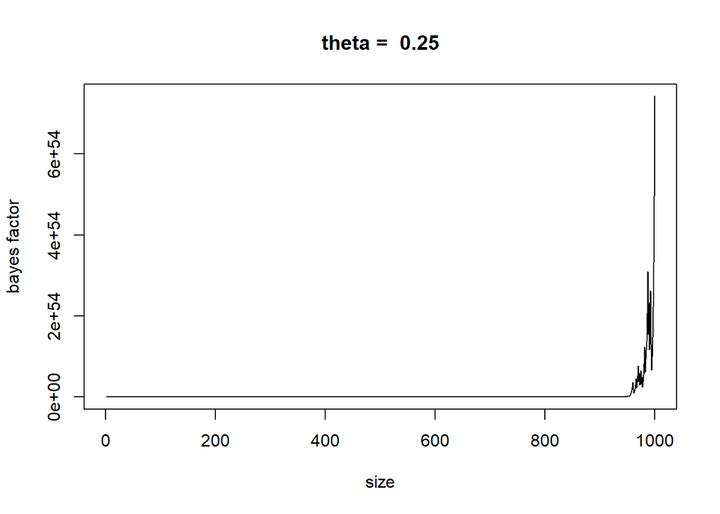

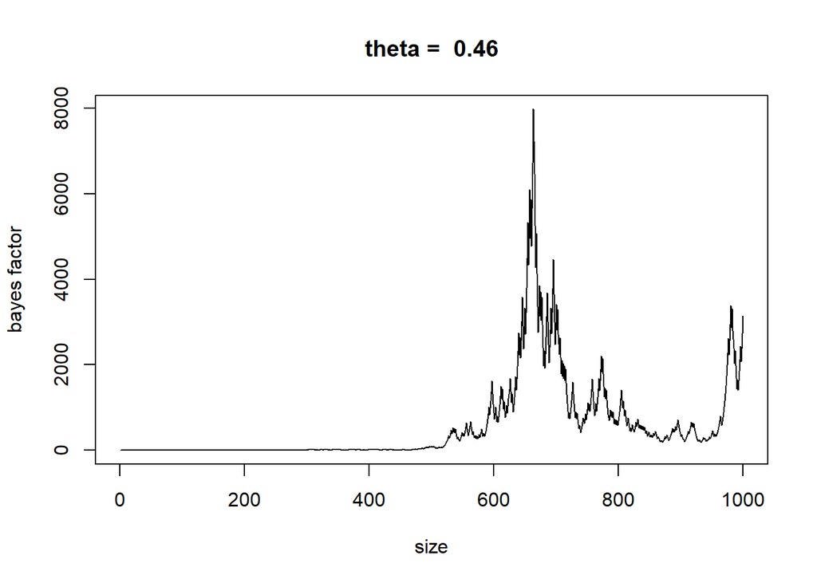

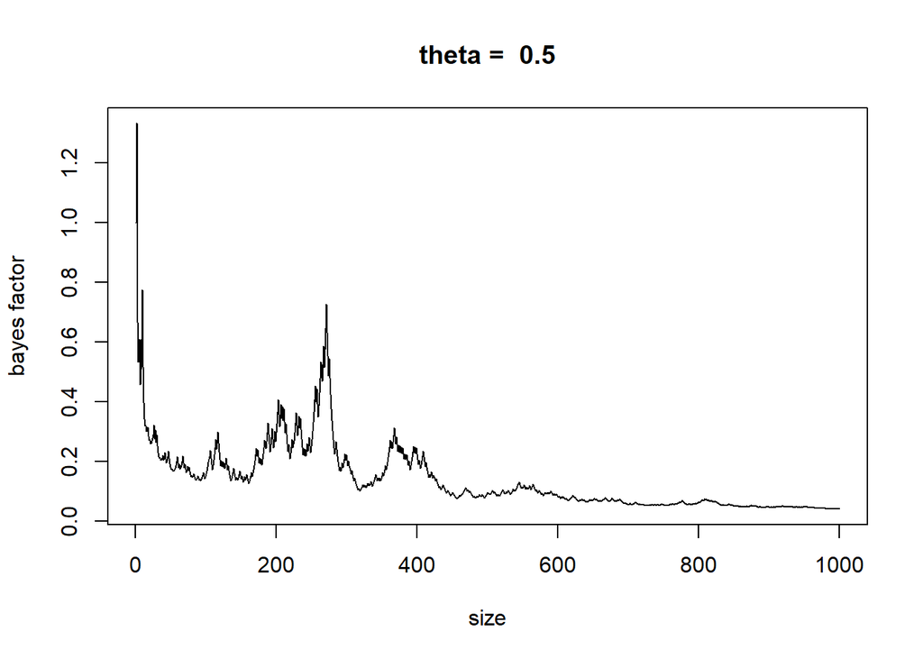

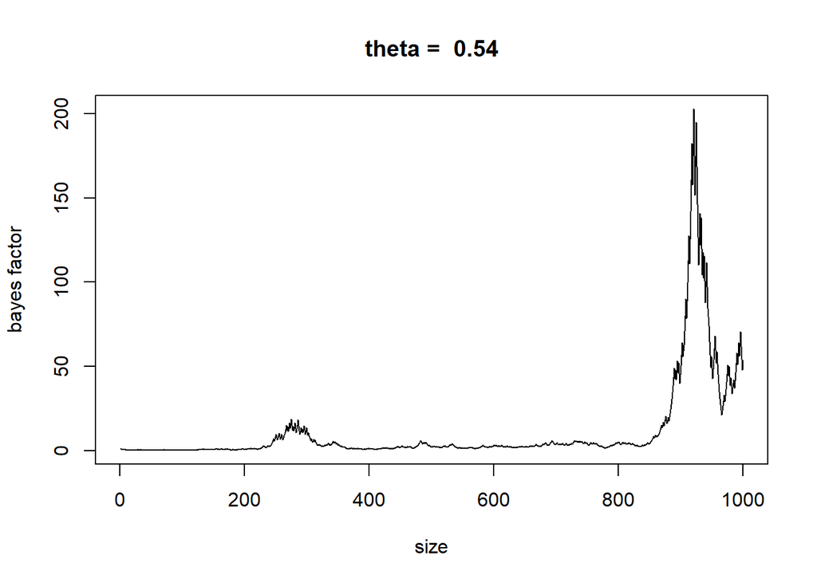

```r
theta_list = c(0.25,0.46,0.5, 0.54)
a = b = 1


for (theta in theta_list){
  n = 1000
  y = c()
  bf10_vec = c()
  for(i in 1:n){
    y_new = rbinom(1,1,theta)
    y = c(y, y_new)
    Y = sum(y)
    bf10 = beta(a+Y, b+i-Y)/(0.5^i)
    bf10_vec = c(bf10_vec, bf10)
  }
  plot(x=1:n, y=bf10_vec, main=paste("theta = ",theta), ylab = "bayes factor", xlab = "size",type="l")
}
```

For second and fourth plots, since the true $\theta$s are close to but not equal to 0.5, the plots for bayes factors don’t have a fixed pattern (however, the range of bayes factor is narrower than that of plot 1), suggesting that data can either support $H_0$ or $H_1$.

### Question 2: Metropolis-Hastings

#### Part (a): Full Conditionals:

$$\begin{align*}
g_{\theta_1}[\theta_1^*|\theta_1^{(s)}, \theta_2^{(s)}] = p(\theta_1^* | y_1,...y_n, \theta_2^{(s)}); \\
g_{\theta_2}[\theta_2^*|\theta_1^{(s)}, \theta_2^{(s)}] = p(\theta_2^* | y_1,...y_n, \theta_2^{(s)}).
\end{align*}$$

$\begin{align*} r &= \frac{p(\theta_1^*, \theta_2^{(s)}|y_{1:n})}{p(\theta_1^{(s)}, \theta_2^{(s)} |y_{1:n})} \frac{g_{\theta_1}[\theta_1^{s}|\theta_1^{(s)}, \theta_2^{(s)}]}{g_{\theta_1}[\theta_1^*|\theta_1^{(s)}, \theta_2^{(s)}]} \\ &= \frac{p(\theta_1^* | y_{1:n}, \theta_2^{(s)}) p(\theta_2^* | y_{1:n})}{p(\theta_1^{(s)} | y_{1:n}, \theta_2^{(s)}) p(\theta_2^* | y_{1:n})} \frac{p(\theta_1^{(s)} | y_{1:n}, \theta_2^{(s)})}{p(\theta_1^* | y_{1:n}, \theta_2^{(s)})} \\ &= 1 \end{align*}$

Similarly, acceptance ratio for $r= \frac{p(\theta_1^{(s)}, \theta_2^*|y_{1:n})}{p(\theta_1^{(s)}, \theta_2^{(s)} |y_{1:n})} \frac{g_{\theta_2}[\theta_2^{s}|\theta_1^{(s)}, \theta_2^{(s)}]}{g_{\theta_2}[\theta_2^*|\theta_1^{(s)}, \theta_2^{(s)}]} = 1$

#### Part (b): Priors:

$$\begin{align*}
g_{\theta_1}[\theta_1^*|\theta_1^{(s)}, \theta_2^{(s)}] = \pi_1(\theta_1^*); \\
g_{\theta_2}[\theta_2^*|\theta_1^{(s)}, \theta_2^{(s)}] = \pi_2(\theta_2^*).
\end{align*}$$

$\begin{align*} r &= \frac{p(\theta_1^*, \theta_2^{(s)}|y_{1:n})}{p(\theta_1^{(s)}, \theta_2^{(s)} |y_{1:n})} \frac{g_{\theta_1}[\theta_1^{s}|\theta_1^{(s)}, \theta_2^{(s)}]}{g_{\theta_1}[\theta_1^*|\theta_1^{(s)}, \theta_2^{(s)}]} \\ &= \frac{p(y_{1:n}|\theta_1^*, \theta_2^{(s)}) \pi_1(\theta_1^*) \pi_2(\theta_2^{(s)})}{p(y_{1:n}|\theta_1^{(s)}, \theta_2^{(s)}) \pi_1(\theta_1^{(s)}) \pi_2(\theta_2^{(s)})} \frac{\pi_1(\theta_1^{(s)})}{\pi_1(\theta_1^*)} \\ &= \frac{p(y_{1:n}|\theta_1^*, \theta_2^{(s)})}{p(y_{1:n}|\theta_1^{(s)}, \theta_2^{(s)})} \end{align*}$

Similarly, acceptance ratio for $r= \frac{p(\theta_1^{(s)}, \theta_2^*|y_{1:n})}{p(\theta_1^{(s)}, \theta_2^{(s)} |y_{1:n})} \frac{g_{\theta_2}[\theta_2^{s}|\theta_1^{(s)}, \theta_2^{(s)}]}{g_{\theta_2}[\theta_2^*|\theta_1^{(s)}, \theta_2^{(s)}]} = \frac{p(y_{1:n}|\theta_1^{(s)}, \theta_2^*)}{p(y_{1:n}|\theta_1^{(s)}, \theta_2^{(s)})}$

#### Part (c): Random Walk:

$$\begin{align*}
g_{\theta_1}[\theta_1^*|\theta_1^{(s)}, \theta_2^{(s)}] = N(\theta_1^{(s)}, \delta^2); \\
g_{\theta_2}[\theta_2^*|\theta_1^{(s)}, \theta_2^{(s)}] = N(\theta_2^{(s)}, \delta^2).
\end{align*}$$

$\begin{align*} r &= \frac{p(\theta_1^*, \theta_2^{(s)}|y_{1:n})}{p(\theta_1^{(s)}, \theta_2^{(s)} |y_{1:n})} \times \frac{g_{\theta_1}[\theta_1^{s}|\theta_1^{(s)}, \theta_2^{(s)}]}{g_{\theta_1}[\theta_1^*|\theta_1^{(s)}, \theta_2^{(s)}]} \\ &= \frac{p(y_{1:n}|\theta_1^*, \theta_2^{(s)}) \pi_1(\theta_1^*) \pi_2(\theta_2^{(s)})}{p(y_{1:n}|\theta_1^{(s)}, \theta_2^{(s)}) \pi_1(\theta_1^{(s)}) \pi_2(\theta_2^{(s)})} \times \frac{\frac{1}{\sqrt{2\pi\sigma^2}}\exp\left(-\frac1{2\delta^2}(\theta_1^{(s)}-\theta_1^{\star})^2\right)}{\frac{1}{\sqrt{2\pi\sigma^2}}\exp\left(-\frac1{2\delta^2}(\theta_1^{\star}-\theta_1^{(s)})^2\right)}\\ &= \frac{p(y_{1:n}|\theta_1^*, \theta_2^{(s)}) \pi_1(\theta_1^*) }{p(y_{1:n}|\theta_1^{(s)}, \theta_2^{(s)}) \pi_1(\theta_1^{(s)})} \end{align*}$

Similarly, acceptance ratio for $r= \frac{p(\theta_1^{(s)}, \theta_2^*|y_{1:n})}{p(\theta_1^{(s)}, \theta_2^{(s)} |y_{1:n})} \frac{g_{\theta_2}[\theta_2^{s}|\theta_1^{(s)}, \theta_2^{(s)}]}{g_{\theta_2}[\theta_2^*|\theta_1^{(s)}, \theta_2^{(s)}]} = \frac{p(y_{1:n}|\theta_1^{(s)}, \theta_2^*) \pi_2(\theta_2^*) }{p(y_{1:n}|\theta_1^{(s)}, \theta_2^{(s)}) \pi_2(\theta_2^{(s)})}$